# New tools for network time series with an application to COVID-19 hospitalisations

# 1 Introduction

# 2 Sample Corbit plots and GNAR simulations

Simulate realisations of differing length coming from the stationary global-$\alpha$ GNAR model below

$$\begin{equation} \label{eq:vector wise representation}
\boldsymbol{X}_{t} = \sum_{k = 1}^{p} \left (\alpha_{k}
\boldsymbol{X}_{t - k} + \sum_{r = 1}^{s_k} \beta_{kr}
\boldsymbol{Z}_{r, t - k} \right ) + \boldsymbol{u}_{t} ,
\end{equation}$$
We use the fiveNet network throughout this notebook for producing the relevant figures.

## 2.1 Producing GNAR simulations

We begin by loading the GNAR package into our session in $\texttt{R}$.

```r
  library(GNAR)
  source("/Users/danielsalnikov/Documents/PhD/my_stuff/papers/corbit_paper/R_scripts/R_scripts_revised/R-Corbit_Covid.R")
```

We simulate a realisation of length one-hundred by using the function $\texttt{GNARsim}$. The code for producing the first simulation also shows howe to compute the $r$-stage adjacency matrices and the weights matrix for the fiveNet network.

```r
  n_sims = 100
  # Compute the r-stage adjacency matrices
  stages_tensor = get_k_stages_adjacency_tensor(
  as.matrix(GNARtoigraph(fiveNet)),
  3)
  # Compute the weights-matrix for the fiveNet network
  W_normalised = weights_matrix(fiveNet, 3)


  # First Simulation GNAR(1, [1])
  sim1 <-  GNARsim(n = n_sims, net=fiveNet,
                 alphaParams = list(rep(0.47, 5)),
                 betaParams = list(c(0.46)))
```

We proceed to compute a Corbit plot for the simulation produced above.

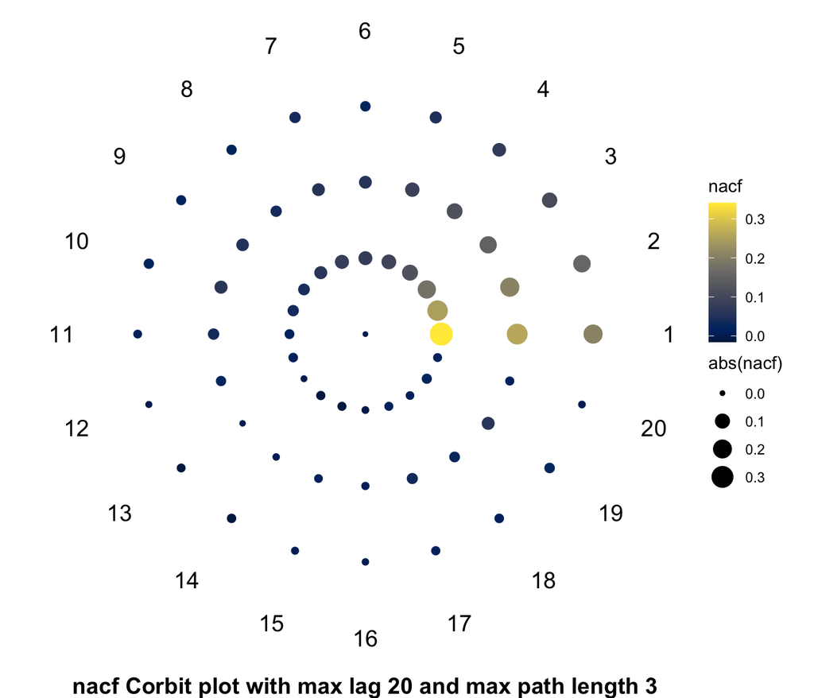

Figure 1: Corbit plot for a realisation of length 100 coming from a stationary global-alpha GNAR(1, [1]) process.

```r
  m_lag = 20
  m_stage = 5
  corbit_plot(vts = sim1, net = fiveNet, max_lag = m_lag, max_stage = 3, viridis_color_option = 'cividis')
```

The Corbit plot above uses the $\texttt{cividis}$ colour scale, however, users can specify any colour scale supported by the $\texttt{viridis}$ package (all of which are colour-blind friendly). Note that the Corbit plot can quicly aid analysts for detecting seasonality and trend in observed realisations of a network time series. We incorporate a seasonal term as a cosine wave of period four into simulation one and produce the new Corbit plot.

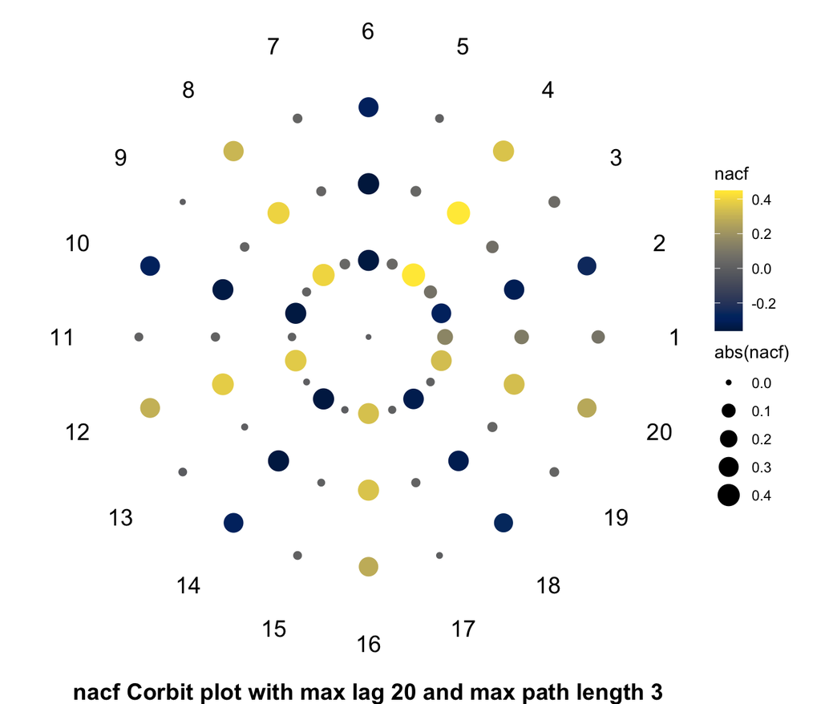

Figure 2: Corbit plot for a realisation of length 100 coming from a seasonal global-alpha GNAR(1, [1]) process.

```r
  m_lag = 20
  m_stage = 5
  sim1_seasonal = vapply(c(1:5), function(x) {sim1[, x] + 2 * (1 + cos(c(1:n_sims) * pi / 2)) }, rep(0, n_sims))
  corbit_plot(vts = sim1_seasonal, net = fiveNet, max_lag = m_lag, max_stage = 3, viridis_color_option = 'cividis')
```

The Corbit plot in Figure 2 successfully reflects the seasonal period every four lags. We incorporate a linear trend into Simulation 1 below, and analyse the resulting Corbit plot below.

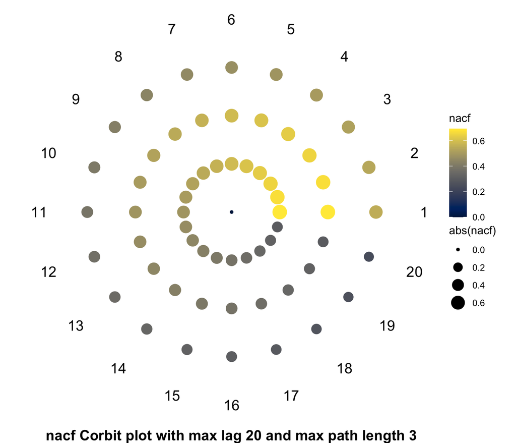

Figure 3: Corbit plot for a realisation of length 100 coming from a global-alpha GNAR(1, [1]) process plus a linear trend.

```r
  m_lag = 20
  m_stage = 5
  sim1_trend = vapply(c(1:5), function(x) {sim1[, x] + c(1:n_sims) }, rep(0, n_sims))
  corbit_plot(vts = sim1_trend, net = fiveNet, max_lag = m_lag, max_stage = 3, viridis_color_option = 'cividis')
```

Finally, we incorporate both a trend and seasonal component into Simulation 1, and analyse the resulting Corbit plot.

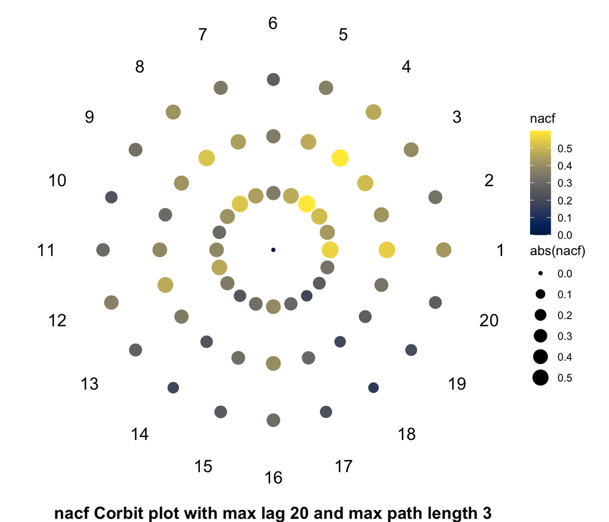

```r
  m_lag = 20
  m_stage = 5
  sim1_trend_seasonal = vapply(c(1:5), function(x) {sim1[, x] + 2 * (1 + cos(c(1:n_sims) * pi / 2)) + c(1:n_sims) / 10 }, rep(0, n_sims))
  corbit_plot(vts = sim1_trend_seasonal, net = fiveNet, max_lag = m_lag, max_stage = 3, viridis_color_option = 'cividis')
```

## 2.2 Recovering model order

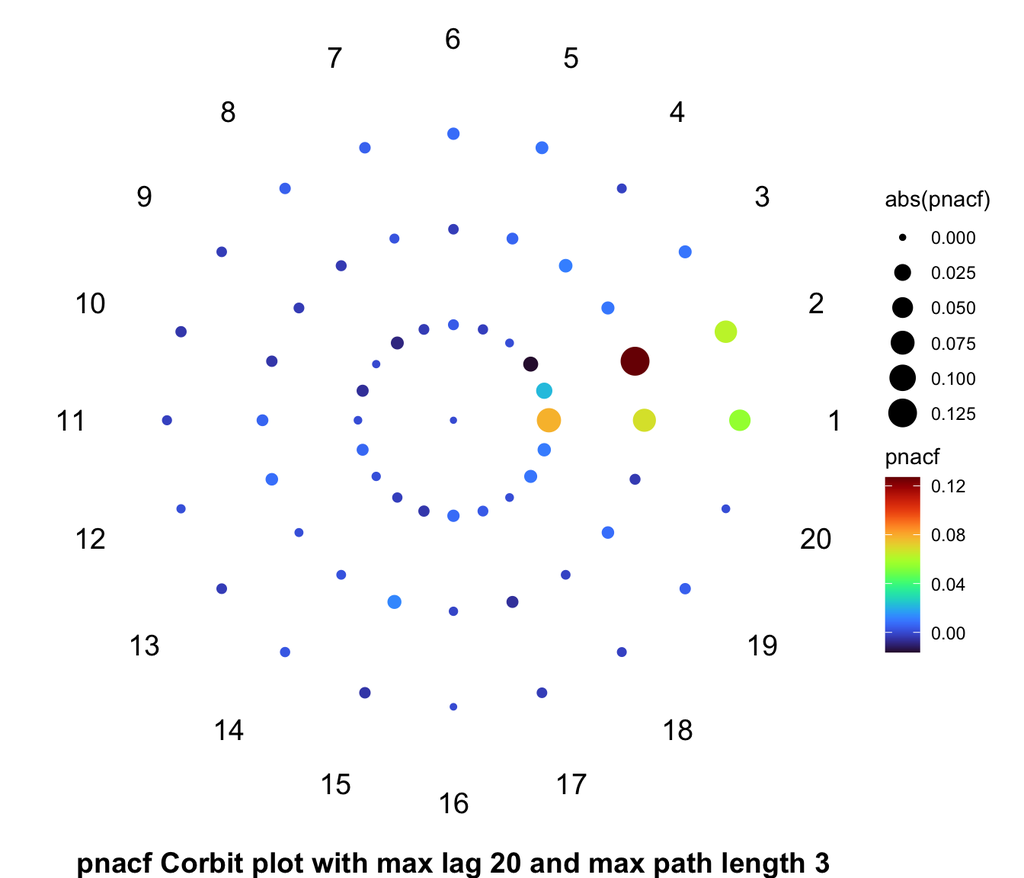

```r
  # Simulate a realisation of length 100 coming from a stationary GNAR(2, [1, 2])
  nsims_2 = 1000
  sim2 <- GNARsim(n = nsims_2, net=fiveNet,
                alphaParams = list(rep(0.12, 5), rep(0.18, 5)),
                betaParams = list(c(0.21), c(-0.32, 0.12)))
  # Compute the corresponding Corbit plot for the PNACF
  corbit_plot(vts = sim2, net = fiveNet, max_lag = m_lag, max_stage = 3, viridis_color_option = 'turbo', partial = "yes")
```

We examine another model.

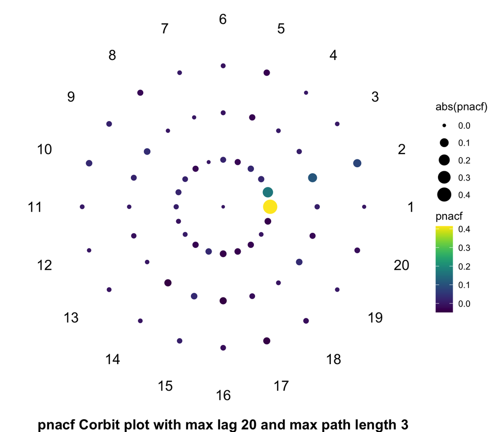

```r
  # Simulate a realisation of length 100 coming from a stationary GNAR(2, [1, 2])
  nsims = 100
  sim2 <- GNARsim(n = nsims, net=fiveNet,
                alphaParams = list(rep(0.21, 5), rep(0.18, 5)),
                betaParams = list(c(0.12), c(0.32, 0.12)))
  # Compute the corresponding Corbit plot for the PNACF
  corbit_plot(vts = sim2, net = fiveNet, max_lag = m_lag, max_stage = 3, viridis_color_option = 'viridis', partial = "yes")
```

We examine a bascc GNAR model

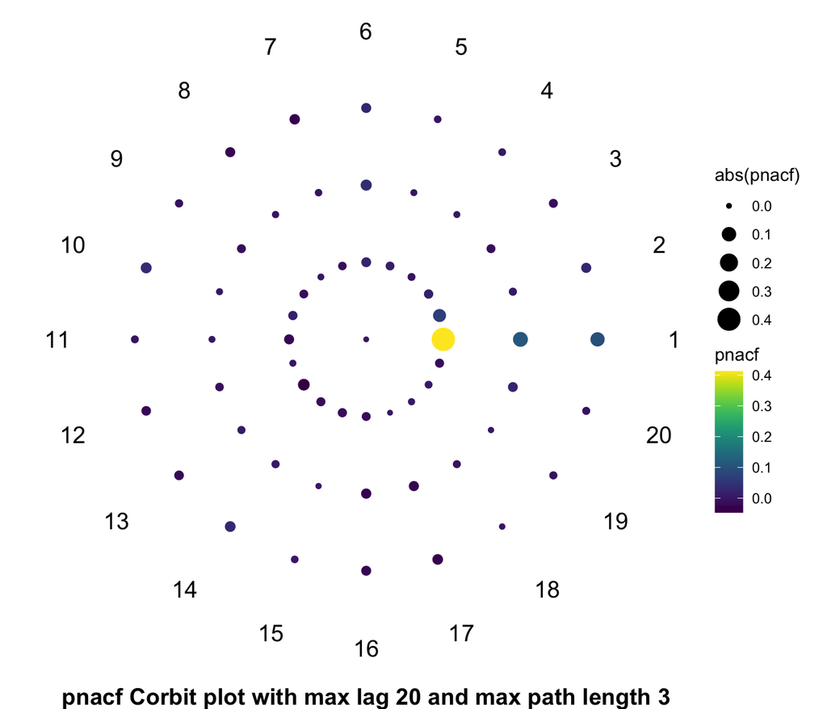

```r
  # Simulate a realisation of length 100 coming from a stationary GNAR(2, [1, 2])
  nsims = 100
  sim2 <- GNARsim(n = nsims, net=fiveNet,
                alphaParams = list(rep(0.35, 5), rep(0.12, 5)),
                betaParams = list(c(0.24), c(0.17)))
  # Compute the corresponding Corbit plot for the PNACF
  corbit_plot(vts = sim2, net = fiveNet, max_lag = m_lag, max_stage = 3, viridis_color_option = 'viridis', partial = "yes")
```

# 3 Analysing the COVID-19 NHS network time-series

We start by loading the NHS trust network time series (included in the $\texttt{GNAR}$ package). The network time series is a realisation of length 452 that corresponds to the logarithm of the daily number of patients transferred to mechanical ventilation beds, i.e., $\log (1 + Y_{i, t})$, where $Y_{i, t}$ is the number of patients transferred to mechanical ventilation beds in NHS trust $i = 1, \dots, 140$ on day $t = 1, \dots, 452$.

```r
# Preliminary objects
# load the NHS trust network time series
covid_data = logMVbedMVC.vts

# Compute the weight matrix for the NHS trusts network
W_nhs_trust = weights_matrix(NHSTrustMVCAug120.net, 1)
```

We visualise the evolution of the series by plotting the sum of the total number of patients transferred to mechanical ventilation beds on each day.

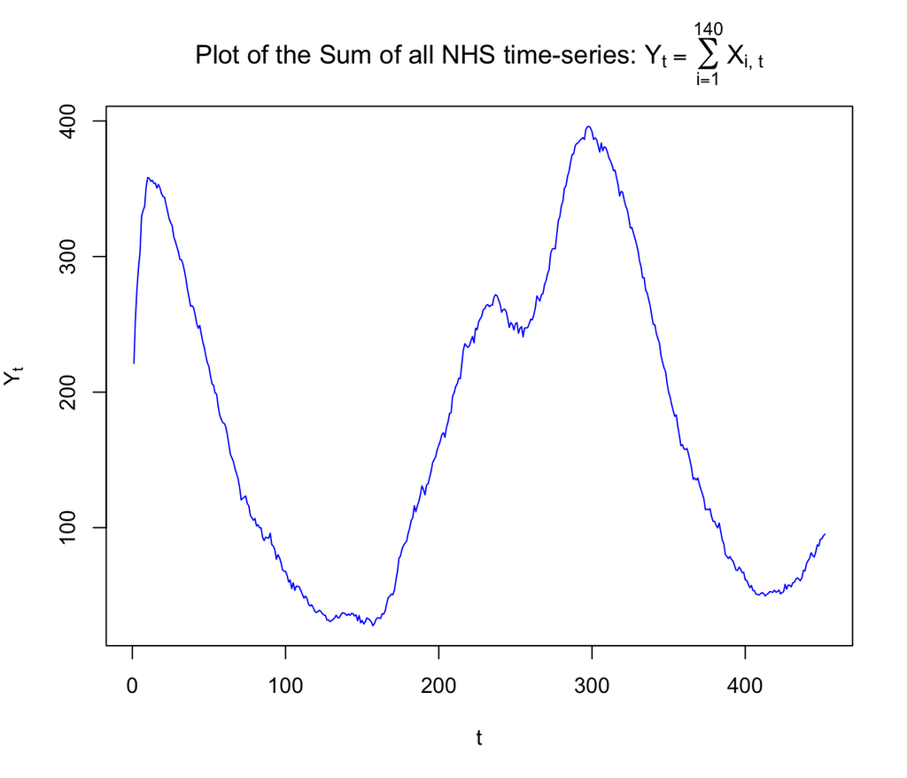

```r
  sum_series = as.ts(rowSums(logMVbedMVC.vts))
  plot(c(1:452), sum_series, 'l', xlab = 't', main = expression(paste('Plot of the Sum of all NHS time-series: ', Y[t] == sum(X["i, t"], i == 1, 140))),
        ylab = expression(Y[t]), col = 'blue')
```

## 3.1 Model order selection

We analyse the network autocorrelation structure by analysing the Corbit plots below. First, we produce the NACF Corbit plot.

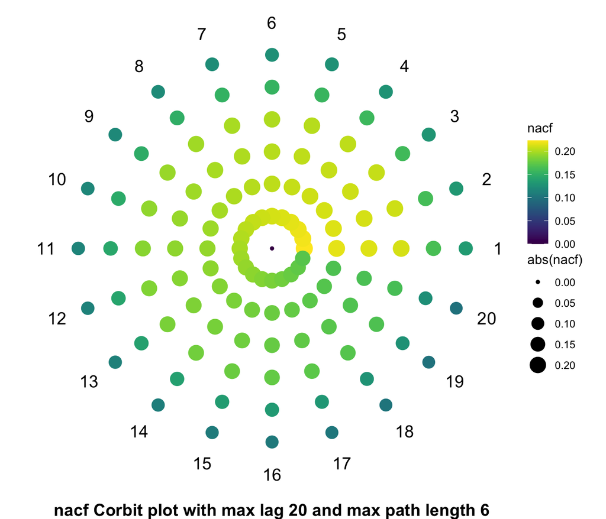

```r
  corbit_plot(covid_data, NHSTrustMVCAug120.net, 20, 6)
```

Subsequently, we analyse the PNACF Corbit plot, which aids model selection and visualising dependence in the data.

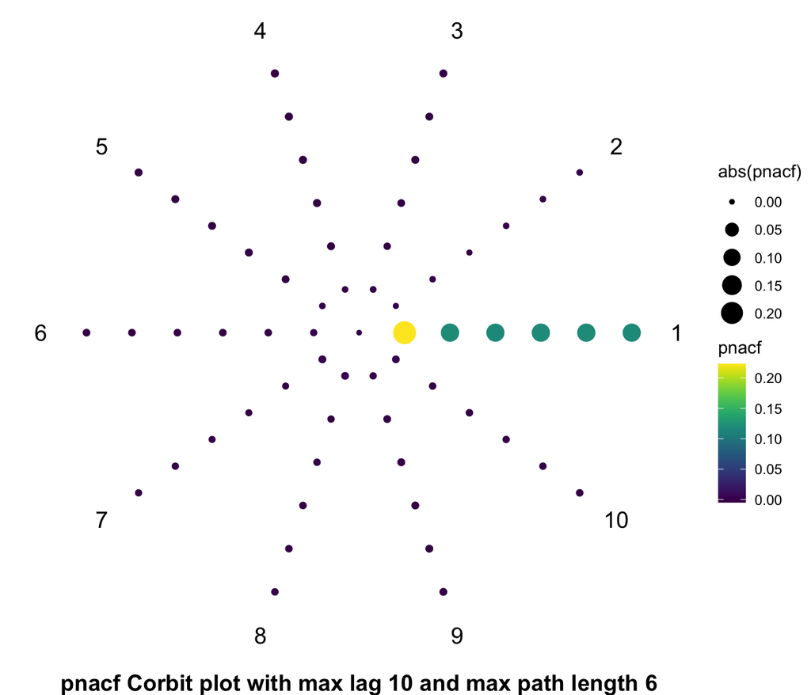

```r
  corbit_plot(covid_data, NHSTrustMVCAug120.net, 10, 6, partial="yes")
```

The Corbit plots above suggest that network autocorrelation cuts-off after the first lag, further, that one-stage neighbous appear to have a stringer correlation than higher-order $r$-stage neighbours. These Corbit plots suggest comparing the following models.

```r
  # Create a table for storing model diagnostic statistics
  GNAR_model_comparison_table <- array(dim = c(6, 5))
  colnames(GNAR_model_comparison_table) <- c("No. of param. ", "  One-Step SE  ", "  Two-Step SE  ", "AIC", "BIC")
```

We compare GNAR fits for the time-steps selected below.

```r
  covid_data_set = covid_data[1:447, ]
  test_set = covid_data[448:452, ]
```

The code for fitting a GNAR$(1, [1])$ is

```r
  # GNAR(1, [1])
  # model order specification
  plag = 1
  stages = c(1)

  # fitting the model
  covid_fit <- GNARfit(covid_data_set, net = NHSTrustMVCAug120.net, alphaOrder = plag, betaOrder = stages)

  # Number of parameters
  GNAR_model_comparison_table[1, 1] = length(covid_fit$mod$coefficients)
  GNAR_model_comparison_table[1, 4] = AIC(covid_fit)
  GNAR_model_comparison_table[1, 5] = BIC(covid_fit)

  # one-step ahead forecast
  one_step = predict(covid_fit)
  GNAR_model_comparison_table[1, 2] = sum((one_step - test_set[1, ])^2)

  # two-step ahead forecast
  new_data = rbind(covid_data_set, one_step)
  new_fit = GNARfit(new_data, net = NHSTrustMVCAug120.net, alphaOrder = plag, betaOrder = stages)
  GNAR_model_comparison_table[1, 3] = sum((predict(new_fit)- test_set[2, ])^2)
```

The code for fitting a GNAR$(1, [6])$ is

```r
  # GNAR(1, [6])
  # model order specification
  plag = 1
  stages = c(6)

  # fitting the model
  covid_fit <- GNARfit(covid_data_set, net = NHSTrustMVCAug120.net, alphaOrder = plag, betaOrder = stages)

  # Number of parameters
  GNAR_model_comparison_table[2, 1] = length(covid_fit$mod$coefficients)
  GNAR_model_comparison_table[2, 4] = AIC(covid_fit)
  GNAR_model_comparison_table[2, 5] = BIC(covid_fit)

  # one-step ahead forecast
  one_step = predict(covid_fit)
  GNAR_model_comparison_table[2, 2] = sum((one_step - test_set[1, ])^2)

  # two-step ahead forecast
  new_data = rbind(covid_data_set, one_step)
  new_fit = GNARfit(new_data, net = NHSTrustMVCAug120.net, alphaOrder = plag, betaOrder = stages)
  GNAR_model_comparison_table[2, 3] = sum((predict(new_fit)- test_set[2, ])^2)
```

The code for fitting a GNAR$(2, [6, 6])$ is

```r
  # GNAR(2, [6, 6])
  # model order specification
  plag = 2
  stages = c(6, 6)

  # fitting the model
  covid_fit <- GNARfit(covid_data_set, net = NHSTrustMVCAug120.net, alphaOrder = plag, betaOrder = stages)

  # Number of parameters
  GNAR_model_comparison_table[3, 1] = length(covid_fit$mod$coefficients)
  GNAR_model_comparison_table[3, 4] = AIC(covid_fit)
  GNAR_model_comparison_table[3, 5] = BIC(covid_fit)

  # one-step ahead forecast
  one_step = predict(covid_fit)
  GNAR_model_comparison_table[3, 2] = sum((one_step - test_set[1, ])^2)

  # two-step ahead forecast
  new_data = rbind(covid_data_set, one_step)
  new_fit = GNARfit(new_data, net = NHSTrustMVCAug120.net, alphaOrder = plag, betaOrder = stages)
  GNAR_model_comparison_table[3, 3] = sum((predict(new_fit)- test_set[2, ])^2)
```

The code for fitting a GNAR$(6, [\boldsymbol{6}])$ is

```r
  # GNAR(6, [6, ..., 6])
  # model order specification
  plag = 6
  stages = rep(6, 6)

  # fitting the model
  covid_fit <- GNARfit(covid_data_set, net = NHSTrustMVCAug120.net, alphaOrder = plag, betaOrder = stages)

  # Number of parameters
  GNAR_model_comparison_table[4, 1] = length(covid_fit$mod$coefficients)
  GNAR_model_comparison_table[4, 4] = AIC(covid_fit)
  GNAR_model_comparison_table[4, 5] = BIC(covid_fit)

  # one-step ahead forecast
  one_step = predict(covid_fit)
  GNAR_model_comparison_table[4, 2] = sum((one_step - test_set[1, ])^2)

  # two-step ahead forecast
  new_data = rbind(covid_data_set, one_step)
  new_fit = GNARfit(new_data, net = NHSTrustMVCAug120.net, alphaOrder = plag, betaOrder = stages)
  GNAR_model_comparison_table[4, 3] = sum((predict(new_fit)- test_set[2, ])^2)
```

The code for fitting a GNAR$(1, [0])$ is

```r
  # GNAR(1, [0])
  # model order specification
  plag = 1
  stages = c(0)

  # fitting the model
  covid_fit <- GNARfit(covid_data_set, net = NHSTrustMVCAug120.net, alphaOrder = plag, betaOrder = stages)

  # Number of parameters
  GNAR_model_comparison_table[5, 1] = length(covid_fit$mod$coefficients)
  GNAR_model_comparison_table[5, 4] = AIC(covid_fit)
  GNAR_model_comparison_table[5, 5] = BIC(covid_fit)

  # one-step ahead forecast
  one_step = predict(covid_fit)
  GNAR_model_comparison_table[5, 2] = sum((one_step - test_set[1, ])^2)

  # two-step ahead forecast
  new_data = rbind(covid_data_set, one_step)
  new_fit = GNARfit(new_data, net = NHSTrustMVCAug120.net, alphaOrder = plag, betaOrder = stages)
  GNAR_model_comparison_table[5, 3] = sum((predict(new_fit)- test_set[2, ])^2)
```

The code for fitting a GNAR$(10, [0])$ is

```r
  # GNAR(10, [0])
  # model order specification
  plag = 10
  stages = rep(0, 10)

  # fitting the model
  covid_fit <- GNARfit(covid_data_set, net = NHSTrustMVCAug120.net, alphaOrder = plag, betaOrder = stages)

  # Number of parameters
  GNAR_model_comparison_table[6, 1] = length(covid_fit$mod$coefficients)
  GNAR_model_comparison_table[6, 4] = AIC(covid_fit)
  GNAR_model_comparison_table[6, 5] = BIC(covid_fit)

  # one-step ahead forecast
  one_step = predict(covid_fit)
  GNAR_model_comparison_table[6, 2] = sum((one_step - test_set[1, ])^2)

  # two-step ahead forecast
  new_data = rbind(covid_data_set, one_step)
  new_fit = GNARfit(new_data, net = NHSTrustMVCAug120.net, alphaOrder = plag, betaOrder = stages)
  GNAR_model_comparison_table[6, 3] = sum((predict(new_fit)- test_set[2, ])^2)
```

We compare the model by printing the following table.

```r
  GNAR_model_comparison_table = round(GNAR_model_comparison_table, 3)

  rownames(GNAR_model_comparison_table) <- c("GNAR(1, [1])", "GNAR(1, [6])", "GNAR(2, [6, 6])", "GNAR(6, [6,:6])", "GNAR(1, [0])", "GNAR(10, [0])")

  print(GNAR_model_comparison_table)
```

```
##                 No. of param.    One-Step SE     Two-Step SE        AIC
## GNAR(1, [1])                 2           5.088           8.808 -452.393
## GNAR(1, [6])                 7           5.064           8.799 -452.532
## GNAR(2, [6, 6])             14           5.166           8.218 -458.883
## GNAR(6, [6,:6])             42           5.238           9.882 -467.350
## GNAR(1, [0])                 1           5.030           8.845 -451.739
## GNAR(10, [0])               10           5.027           8.654 -472.229
##                      BIC
## GNAR(1, [1])    -452.375
## GNAR(1, [6])    -452.468
## GNAR(2, [6, 6]) -458.755
## GNAR(6, [6,:6]) -466.964
## GNAR(1, [0])    -451.730
## GNAR(10, [0])   -472.137
```

## 3.2 Comparison with VAR models

We compare a GNAR$(1, [1])$ with VAR and sparse VAR models. We begin by loading the required libraries.

```r
  library(forecast)
  library(vars)
  library(sparsevar)
```

We perform one-step ahead prediction ten times. The starting time-step and error vectors are initialised below.

```r
  # number of one-step ahead predictions
  # dummt counter variable
  k = 0
  t_steps = 10

  # starting point
  covid_data = logMVbedMVC.vts
  initial_start = nrow(covid_data) - t_steps
  decimal_digits = 3

  # AR model prediction error
  ar_pe = rep(0, t_steps)

  # global-alpha GNAR model prediction error
  gnar_pe = rep(0, t_steps)
  # local-alpha GNAR model prediction error
  gnar_no_global_pe = rep(0, t_steps)

  # VAR prediction error
  var_pe = rep(0, t_steps)

  # restricted VAR prediction error
  res_var_pe = rep(0, t_steps)

  # sparse VAR prediction error
  sparse_var_pe = rep(0, t_steps)
```

We perform one-ahead forecasting ten times and save the squared error.

```r
  for (i in 1:t_steps) {
  # initialise the comparison table
  output <- matrix(rep(0, 18), nrow = 6, ncol = 3)
  train_end = initial_start + k
  test_point = train_end + 1

# We compare the GNAR models in this script
# 140 AR(1) models
  arforecast <- apply(covid_data[1:train_end, ], 2, function(x){
    forecast(auto.arima(x, d = 0, D = 0, max.p = 1, max.q = 0,
             max.P = 0, max.Q = 0, stationary = TRUE, seasonal = FALSE, ic = 'bic',
             allowmean = FALSE, allowdrift = FALSE, trace = FALSE), h = 1)$mean
  })
  output[5, 2] = "$140$"
  output[5, 1] = "AR(1)"
  output[5, 3] = round(sum((arforecast - covid_data[test_point, ])^2), digits = decimal_digits)
  ar_pe[i] = output[5, 3]

# GNAR(1, [1]) global-alpha fit
  covid_fit <- GNARfit(covid_data[1:train_end, ], net = NHSTrustMVCAug120.net, alphaOrder = 1, betaOrder = rep(1, 1))
  output[1, 2] = 2
  output[1, 3] = round(sum((predict(covid_fit) - covid_data[test_point, ])^2), digits = decimal_digits)
  gnar_pe[i] = output[1, 3]
  output[1, 1] = "GNAR(1, [1])"

# GNAR(1, [1]) local-alpha fit
  covid_fit <- GNARfit(covid_data[1:train_end, ], net = NHSTrustMVCAug120.net, alphaOrder = 1, betaOrder = rep(1, 1), globalalpha=FALSE)
  output[6, 2] = 141
  output[6, 3] = round(sum((predict(covid_fit) - covid_data[test_point, ])^2), digits = decimal_digits)
  gnar_no_global_pe[i] = output[6, 3]
  output[6, 1] = "GNAR(1, [1])*"


# Restricted VAR(1) model
  varforecast <- predict(restrict(VAR(covid_data[1:train_end, ], p = 1, type = 'none')), n.ahead = 1)
  get_var_fcst <- function(x){return (x[1])}
  var_point_fcst <- unlist(lapply(varforecast$fcst, get_var_fcst))
  output[3, 3] = round(sum((var_point_fcst - covid_data[test_point, ])^2), digits = decimal_digits)
  res_var_pe[i] = output[3, 3]
  active = 0.0
  aux = varforecast$model$varresult
  for (ii in 1:ncol(covid_data)) {
    for (j in 1:length(aux[[ii]][[1]])){
      if (abs(aux[[ii]][[1]][j]) > 0.0) {
        active = active + 1
      }
    }
  }
  output[3, 1] = "Res. VAR(1)"
  output[3, 2] = active


# Classic VAR(1) model
  varforecast <- predict(VAR(covid_data[1:train_end, ], p = 1, type = 'none'), n.ahead = 1)
  get_var_fcst <- function(x){return (x[1])}
  var_point_fcst <- unlist(lapply(varforecast$fcst, get_var_fcst))
  output[2, 2] = "$140^2$"
  output[2, 3] = round(sum((var_point_fcst - covid_data[test_point, ])^2), digits = decimal_digits)
  var_pe[i] = output[2, 3]
  output[2, 1] = "VAR(1)"

# Sparse VAR(1) model
  sparse_var_forecast <- fitVAR(covid_data[1:train_end, ], p = 1)
  xhat = sparse_var_forecast$A[[1]] %*% covid_data[train_end, ]
  output[4, 3] = round(sum((xhat - covid_data[test_point, ])^2), digits = decimal_digits)
  sparse_var_pe[i] = output[4, 3]
  b = sparse_var_forecast$A[[1]]
  b[abs(b) > 0.0] = 1
  output[4, 2] = sum(rowSums(b))
  output[4, 1] = "Sparse VAR(1)"
##########################
  # stack all ten tables
  colnames(output) <- c("Model", "Active Parameters", "One-Step SPE")
  print(output)
  cat("\n############################################# \n#############################################\n")
  if (i == 1) {
    out_data = output
  } else {
    out_data = rbind(out_data, output)
  }
  k = k + 1
  }
```

```
##      Model           Active Parameters One-Step SPE
## [1,] "GNAR(1, [1])"  "2"               "5.441"
## [2,] "VAR(1)"        "$140^2$"         "11.613"
## [3,] "Res. VAR(1)"   "3821"            "9.902"
## [4,] "Sparse VAR(1)" "3277"            "10.269"
## [5,] "AR(1)"         "$140$"           "82.055"
## [6,] "GNAR(1, [1])*" "141"             "5.324"
##
## #############################################
## #############################################
##      Model           Active Parameters One-Step SPE
## [1,] "GNAR(1, [1])"  "2"               "7.86"
## [2,] "VAR(1)"        "$140^2$"         "12.804"
## [3,] "Res. VAR(1)"   "3712"            "11.504"
## [4,] "Sparse VAR(1)" "2992"            "11.533"
## [5,] "AR(1)"         "$140$"           "78.748"
## [6,] "GNAR(1, [1])*" "141"             "7.833"
##
## #############################################
## #############################################
##      Model           Active Parameters One-Step SPE
## [1,] "GNAR(1, [1])"  "2"               "10.286"
## [2,] "VAR(1)"        "$140^2$"         "12.52"
## [3,] "Res. VAR(1)"   "3730"            "11.605"
## [4,] "Sparse VAR(1)" "3033"            "13.008"
## [5,] "AR(1)"         "$140$"           "82.571"
## [6,] "GNAR(1, [1])*" "141"             "10.173"
##
## #############################################
## #############################################
##      Model           Active Parameters One-Step SPE
## [1,] "GNAR(1, [1])"  "2"               "12.953"
## [2,] "VAR(1)"        "$140^2$"         "17.762"
## [3,] "Res. VAR(1)"   "3812"            "14.472"
## [4,] "Sparse VAR(1)" "3283"            "15.057"
## [5,] "AR(1)"         "$140$"           "86.781"
## [6,] "GNAR(1, [1])*" "141"             "12.676"
##
## #############################################
## #############################################
```

[output cut: 45 more lines]

```
## [5,] "AR(1)"         "$140$"           "91.151"
## [6,] "GNAR(1, [1])*" "141"             "8.607"
##
## #############################################
## #############################################
##      Model           Active Parameters One-Step SPE
## [1,] "GNAR(1, [1])"  "2"               "8.623"
## [2,] "VAR(1)"        "$140^2$"         "15.693"
## [3,] "Res. VAR(1)"   "3794"            "13.258"
## [4,] "Sparse VAR(1)" "3299"            "15.715"
## [5,] "AR(1)"         "$140$"           "96.361"
## [6,] "GNAR(1, [1])*" "141"             "8.546"
##
## #############################################
## #############################################
```

```r
  comp_results = cbind(as.numeric(gnar_pe), as.numeric(sparse_var_pe), as.numeric(res_var_pe), as.numeric(var_pe), as.numeric(ar_pe), as.numeric(gnar_no_global_pe))
  print(colMeans(comp_results))
```

```
## [1]  7.4145 11.3526 10.6135 12.2759 87.4015  7.3134
```

```r
  aux = out_data[out_data[, 1] == 'Sparse VAR(1)']
  print(mean(as.numeric(aux[11:20])))
```

```
## [1] 3131.3
```

```r
  # 3089
  aux = out_data[out_data[, 1] == 'Res. VAR(1)']
  print(mean(as.numeric(aux[11:20])))
```

```
## [1] 3772.9
```

```r
  # 3773
  all_summary = matrix(rep(0, 18), nrow = 6, ncol = 3)
  all_summary[, 1] = colMeans(comp_results)
  all_summary[, 2] = c(2, 2962, 3767, 19600, 140, 141)
  for (j in 1:ncol(comp_results)) {
    all_summary[j, 3] = sd(comp_results[, j])
  }
  print(all_summary)
```

```
##         [,1]  [,2]     [,3]
## [1,]  7.4145     2 2.977923
## [2,] 11.3526  2962 2.851550
## [3,] 10.6135  3767 2.482946
## [4,] 12.2759 19600 3.184071
## [5,] 87.4015   140 5.146953
## [6,]  7.3134   141 2.900672
```

## 3.4 Analysing node impact on network autocorrelation

We analyse the impact individual nodes have on network autocorrelation for our choice of model order. Further, we study the relative importance each node has in pair-wise node regressions, and compare the one-lag cross-correlation matrix with a heat map obtained from Theorem 2, this comparison shows the self-similar clustering behaviour for pair-wise correlations.

We start by defining the different waves of the pandemic and looking at a R-Corbit plot of the realised network autocorrelation.

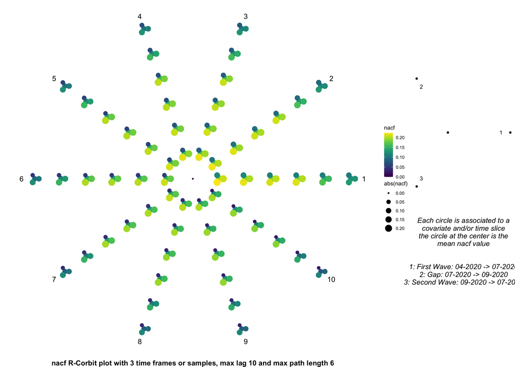

```r
  covid_data = logMVbedMVC.vts
  W_nhs_network = weights_matrix(NHSTrustMVCAug120.net, 6)


  first_wave = covid_data[1:100, ]
  gap = covid_data[101:177, ]
  second_wave = covid_data[178:447, ]
  time_slices = c('First Wave: 04-2020 -> 07-2020', 'Gap: 07-2020 -> 09-2020', 'Second Wave: 09-2020 -> 07-2021')
  R_corbit_plot(list(first_wave, gap, second_wave), list(NHSTrustMVCAug120.net), 10, 6, weight_matrices = list(W_nhs_network), same_net = 'yes',
            frame_names = time_slices)
```

The PNACF R-Corbit plot is produced with the code below.

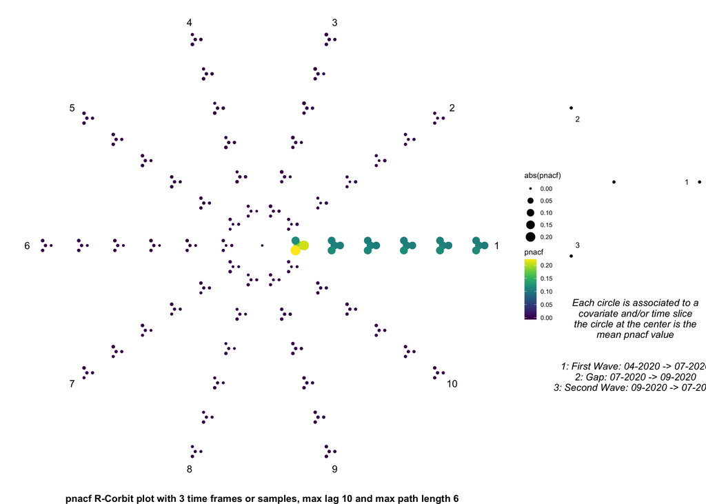

```r
  R_corbit_plot(list(first_wave, gap, second_wave), list(NHSTrustMVCAug120.net), 10, 6, weight_matrices = list(W_nhs_network), same_net = 'yes',
            frame_names = time_slices, partial = 'yes')
```

We explore the importance individual nodes have for predicting each other with the heat-map below. Note that it is not symmetric, the yellow colour highlights the strongest pair-wise realations according to formula (18) in $\textbf{New tools for network time series with an application to COVID-19 hospitalisations}$.

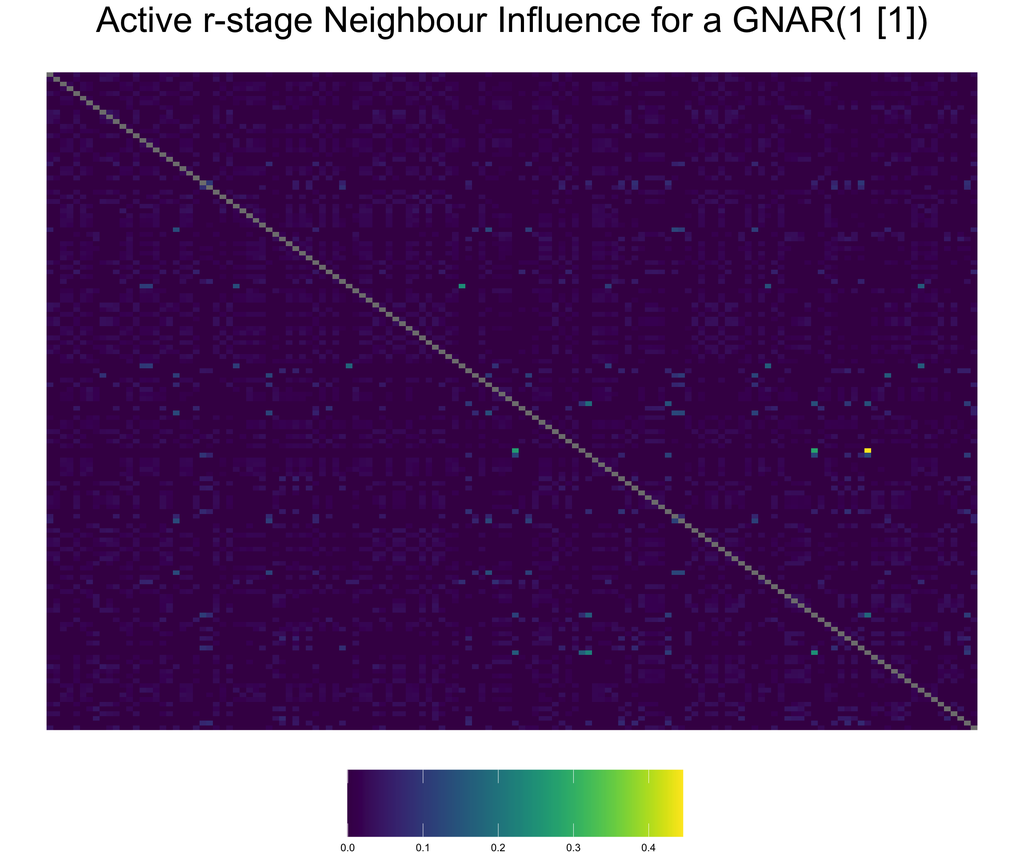

```r
 active_node_plot(second_wave, NHSTrustMVCAug120.net, 1, c(1))
```

We continue by looking at the impact each node has on the total network autocorrelation (i.e., the column in $\mathbf{W}$ that dominates autocorrelation). We do this by producing the node relevance hierarchy and plot. This is computed with (17).

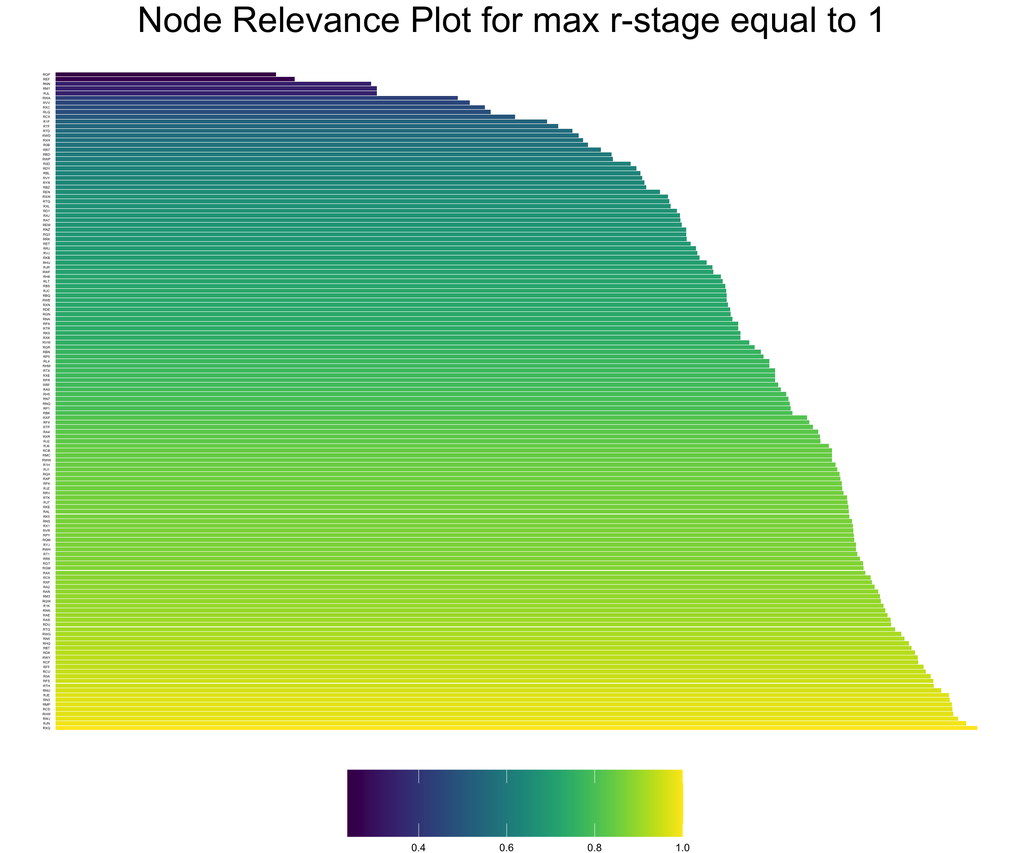

```
##
## [[2]]
##     Node Relevance
## 1    RGP 0.2388075
## 2    REF 0.2590320
## 3    RNN 0.3423592
## 4    RM1 0.3481702
## 5    RJL 0.3482829
## 6    RWA 0.4361727
## 7    RVV 0.4489792
## 8    RXC 0.4656740
## 9    RLQ 0.4718158
## 10   RCX 0.4981928
## 11   R1F 0.5329288
## 12   RTF 0.5451035
```

[output cut: 128 more lines]

```r
  node_relevance_plot(NHSTrustMVCAug120.net, 1, colnames(covid_data), 1)
```

We compare the observed one-lag cross-correlation and the structure Theorem 2 suggests in the plots below. Note that the neighbourhood and self-similarity suggests that outbreaks are mostly dependent on direct neighbours, i.e., the virus cannot reach nodes by jumps it must traverse all NHS trusts (i.e., nodes) in a path between two places for instigating an outbreak.

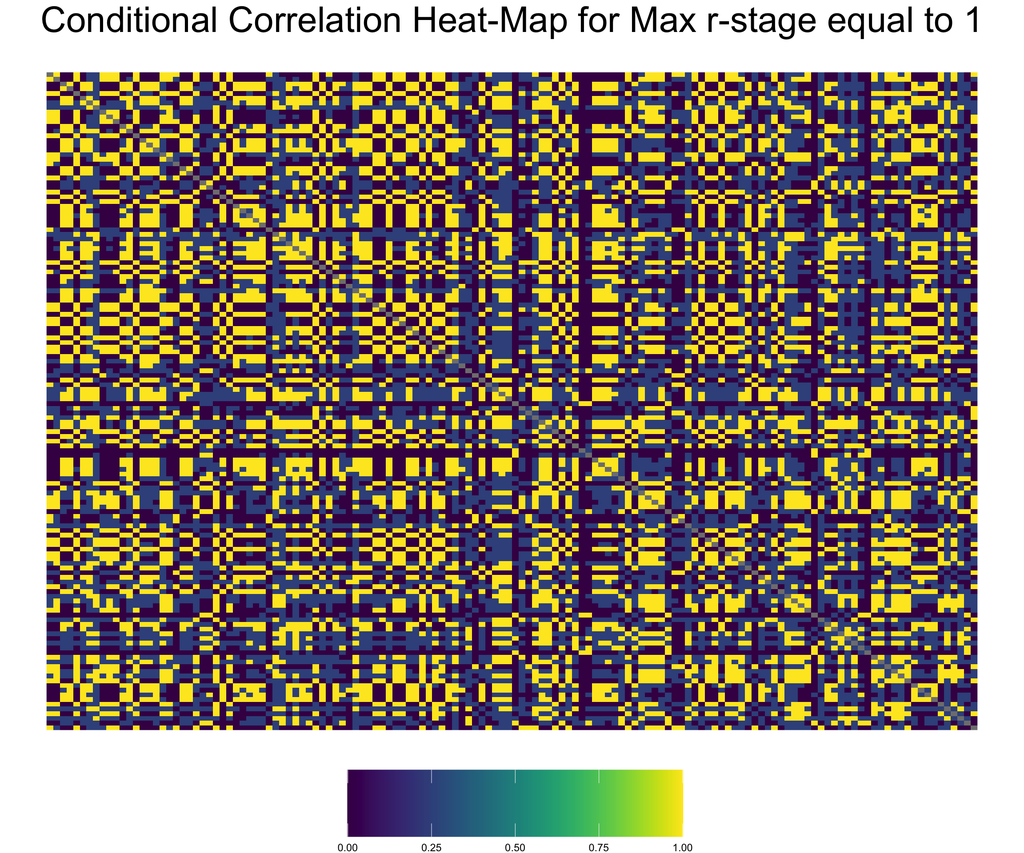

```r
# larger r-stage changes the correlation structure
  max_r_stage = 1
  local_relevance_plot(NHSTrustMVCAug120.net, max_r_stage)
```

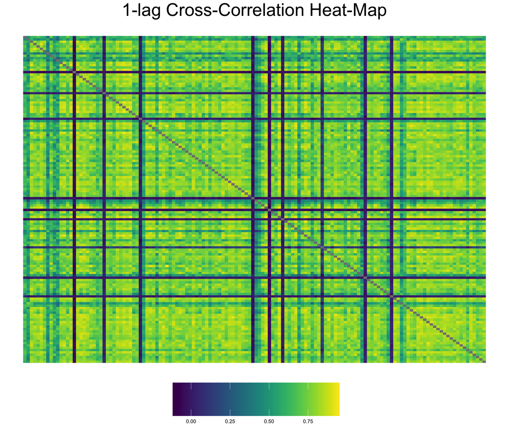

```r
  cross_correlation_plot(1, covid_data)
```

All three plots, except for the node relevance one, have the following column and row names.

```r
  dummy_vec = vapply(c(1:140), function(x) {cat(paste0(x, ": ", colnames(covid_data)[x]), "\n"); return (0)}, 0)
```

```
## 1: RCF
## 2: RBS
## 3: RTK
## 4: RF4
## 5: RFF
## 6: R1H
## 7: RC9
## 8: RQ3
## 9: RXL
## 10: RMC
## 11: RAE
## 12: RXH
## 13: RXQ
## 14: RWY
## 15: RGT
```

[output cut: 125 more lines]